# Data Visualization

## 1. Basic plots and functions

```python
import pandas as pd
import matplotlib.pyplot as plt
```

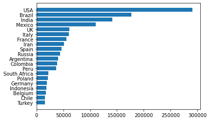

```python
top20_deathtoll = pd.read_csv('top20_deathtoll.csv')

plt.barh(top20_deathtoll['Country_Other'],
         top20_deathtoll['Total_Deaths'])
plt.show()
```

### plt.subplots() function

An object-oriented (OO) interface: we use methods to create and modify plots.

```
Figure(432x288) <class 'matplotlib.figure.Figure'>
AxesSubplot(0.125,0.125;0.775x0.755) <class 'matplotlib.axes._subplots.AxesSubplot'>
```

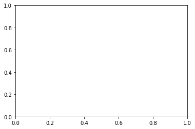

```python
fig, ax = plt.subplots()
print(fig, type(fig))
print(ax, type(ax))
```

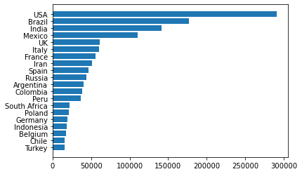

```python
fig, ax = plt.subplots()
ax.barh(top20_deathtoll['Country_Other'],
        top20_deathtoll['Total_Deaths'])
plt.show()
```

### Adjust the figure size

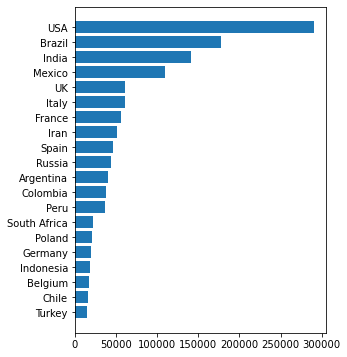

```python
fig, ax = plt.subplots(figsize=(4.5,6))
ax.barh(top20_deathtoll['Country_Other'],
        top20_deathtoll['Total_Deaths'])
plt.show()
```

Generally, a graph has three elements:

- Data elements: the numbers and the categories visually represented and the relationships between them.
- Structural elements: the axes, the ticks, the legend, the grid, etc.
- Decorations: extra colors, shapes, artistic drawings etc.

Edward Tufte theorized the principle of maximizing data elements in his book The Visual Display of Quantitative Information (1983). From the total amount of ink used for printing a graph, some of the ink goes to show the data — that is the data-ink. As a sidenote, Tufte worked on his book in the 1980s, when most graphs were printed on paper using ink.

Tufte named the principle of maximizing data elements as maximizing the data-ink ratio. The data-ink ratio is the proportion of data-ink from the total ink:

```
              Data-ink ratio =  data-ink / total ink used to print the graph
```

### Remove the spines - ax.spines[ ].set_visible() and tick_params()

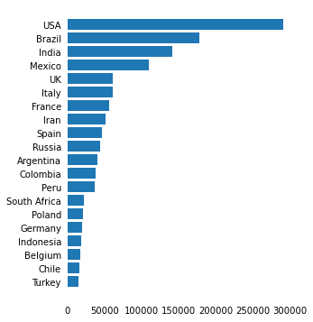

```python
fig, ax = plt.subplots(figsize=(4.5,6))
ax.barh(top20_deathtoll['Country_Other'],
        top20_deathtoll['Total_Deaths'])

## Remove spines

for i in ['left', 'right', 'top', 'bottom']:
    ax.spines[i].set_visible(False)

## Remove ticks
ax.tick_params(bottom=False, left=False)
plt.show()
```

### Bar thickness and set_xticks

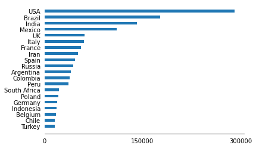

```python
## set the thickness of each bar

fig, ax = plt.subplots()
ax.barh(top20_deathtoll['Country_Other'],
        top20_deathtoll['Total_Deaths'], height = 0.45)

ax.spines['top'].set_visible(False)
ax.spines['right'].set_visible(False)
ax.spines['left'].set_visible(False)
ax.tick_params(bottom=False, left=False)
## set the xticks

ax.set_xticks([0,150000,300000])
plt.show()
```

### ax.xaxis.tick_top() and tick_params

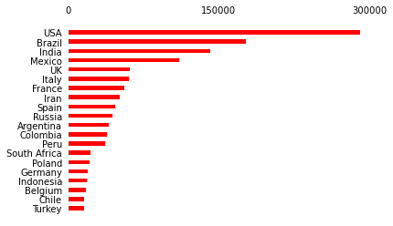

```python
## locate the x axis on the top of the plot.

fig, ax = plt.subplots()
ax.barh(top20_deathtoll['Country_Other'],
        top20_deathtoll['Total_Deaths'], height = 0.45, color='red')

for i in ['left', 'right', 'top', 'bottom']:
    ax.spines[i].set_visible(False)

ax.set_xticks([0,150000, 300000])
ax.xaxis.tick_top()

ax.tick_params(top=False, left=False)
ax.tick_params(axis='x', color='grey')
```

### ax.text() to display title or subtitle

- x / y: the coordinates that give the position of the text.
- s: the text content.

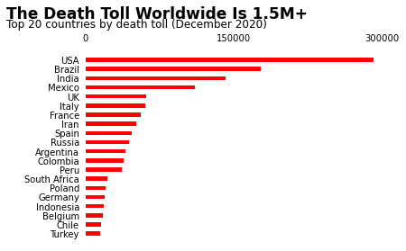

```python
fig, ax = plt.subplots()
ax.barh(top20_deathtoll['Country_Other'],
        top20_deathtoll['Total_Deaths'], height = 0.45, color='red')

for i in ['left', 'right', 'top', 'bottom']:
    ax.spines[i].set_visible(False)

ax.set_xticks([0,150000, 300000])
ax.xaxis.tick_top()

ax.tick_params(top=False, left=False)
ax.tick_params(axis='x', color='grey')

ax.text(x=-80000, y=23.5,
        s='The Death Toll Worldwide Is 1.5M+',
        weight='bold', size=17)

ax.text(x=-80000, y=22.5,
        s='Top 20 countries by death toll (December 2020)',
        size=12)
plt.show()
```

### set_xticklabels() and ax.axvline()

parameters in axvline()

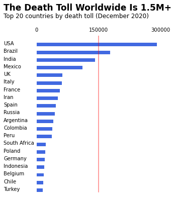

```python
fig, ax = plt.subplots(figsize=(4.5,6))
ax.barh(top20_deathtoll['Country_Other'],
        top20_deathtoll['Total_Deaths'],
        height=0.45, color='royalblue')

for i in ['left', 'right', 'top', 'bottom']:
    ax.spines[i].set_visible(False)

ax.set_xticks([0,150000,300000])
ax.xaxis.tick_top()

ax.tick_params(left=False, top=False)
ax.tick_params(axis='x', color='gray')

ax.text(x=-80000, y=23.5,
        s='The Death Toll Worldwide Is 1.5M+',
        weight='bold', size=17)

ax.text(x=-80000, y=22.5,
        s='Top 20 countries by death toll (December 2020)',
        size=12)

ax.set_xticklabels(['0','150000','300000'])

ax.set_yticklabels([])

country_names = top20_deathtoll['Country_Other']

for i, name in zip(range(21), country_names):
    ax.text(x=-80000, y = i-0.025, s=name)

ax.axvline(x=150000, ymin=0.045, color='red', alpha=0.5)
plt.show()
```

## 2. Multiple plots

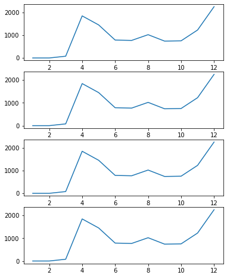

```python
import pandas as pd
import matplotlib.pyplot as plt
death_toll = pd.read_csv('covid_avg_deaths.csv')

fig, (ax1,ax2, ax3, ax4) = plt.subplots(nrows = 4,
                                        ncols = 1,
                                       figsize=(6,8))

ax1.plot(death_toll['Month'], death_toll['New_deaths'])
ax2.plot(death_toll['Month'], death_toll['New_deaths'])
ax3.plot(death_toll['Month'], death_toll['New_deaths'])
ax4.plot(death_toll['Month'], death_toll['New_deaths'])
plt.show()
```

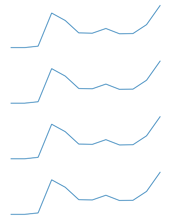

```python
death_toll = pd.read_csv('covid_avg_deaths.csv')
fig, (ax1, ax2, ax3, ax4) = plt.subplots(nrows=4, ncols=1,
                                         figsize=(6,8))

axes = [ax1, ax2, ax3, ax4]

for ax in axes:
    ax.plot(death_toll['Month'], death_toll['New_deaths'])
    ax.set_xticklabels([])
    ax.set_yticklabels([])
    ax.tick_params(left=False, bottom=False)
    for location in ['left', 'right', 'top', 'bottom']:
        ax.spines[location].set_visible(False)
plt.show()
```

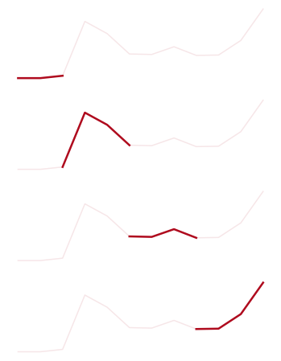

```python
death_toll = pd.read_csv('covid_avg_deaths.csv')
fig, (ax1, ax2, ax3, ax4) = plt.subplots(nrows=4, ncols=1,
                                         figsize=(6,8))

axes = [ax1, ax2, ax3, ax4]

for ax in axes:
    ax.plot(death_toll['Month'], death_toll['New_deaths'], color='#af0b1e', alpha=0.1)
    ax.set_xticklabels([])
    ax.set_yticklabels([])
    ax.tick_params(left=False, bottom=False)
    for location in ['left', 'right', 'top', 'bottom']:
        ax.spines[location].set_visible(False)

ax1.plot(death_toll['Month'][:3], death_toll['New_deaths'][:3],
         color='#af0b1e', linewidth=2.5)
ax2.plot(death_toll['Month'][2:6], death_toll['New_deaths'][2:6],
         color='#af0b1e', linewidth=2.5)
ax3.plot(death_toll['Month'][5:9],death_toll['New_deaths'][5:9],
         color='#af0b1e', linewidth=2.5)
ax4.plot(death_toll['Month'][8:12],death_toll['New_deaths'][8:12],
         color='#af0b1e', linewidth=2.5)
plt.show()
```

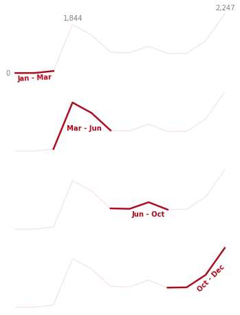

```python
death_toll = pd.read_csv('covid_avg_deaths.csv')
fig, (ax1, ax2, ax3, ax4) = plt.subplots(nrows=4, ncols=1,
                                         figsize=(6,8))

axes = [ax1, ax2, ax3, ax4]

for ax in axes:
    ax.plot(death_toll['Month'], death_toll['New_deaths'], color='#af0b1e', alpha=0.1)
    ax.set_xticklabels([])
    ax.set_yticklabels([])
    ax.tick_params(left=False, bottom=False)
    for location in ['left', 'right', 'top', 'bottom']:
        ax.spines[location].set_visible(False)

ax1.plot(death_toll['Month'][:3], death_toll['New_deaths'][:3],
         color='#af0b1e', linewidth=2.5)
ax2.plot(death_toll['Month'][2:6], death_toll['New_deaths'][2:6],
         color='#af0b1e', linewidth=2.5)
ax3.plot(death_toll['Month'][5:9],death_toll['New_deaths'][5:9],
         color='#af0b1e', linewidth=2.5)
ax4.plot(death_toll['Month'][8:12],death_toll['New_deaths'][8:12],
         color='#af0b1e', linewidth=2.5)

ax1.text(0.5, -80, '0', alpha=0.5)
ax1.text(3.5, 2000, '1,844', alpha=0.5)
ax1.text(11.5, 2400, '2,247', alpha=0.5)

ax1.text(1.1, -300, 'Jan - Mar', color='#af0b1e',
         weight='bold', rotation=3)
ax2.text(3.7, 800, 'Mar - Jun', color='#af0b1e', weight='bold')
ax3.text(7.1,500, 'Jun - Oct', color='#af0b1e', weight='bold')
ax4.text(10.5, 600, 'Oct - Dec', color='#af0b1e', weight='bold', rotation = 45)


plt.show()
```

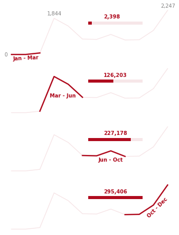

```python
death_toll = pd.read_csv('covid_avg_deaths.csv')
fig, (ax1, ax2, ax3, ax4) = plt.subplots(nrows=4, ncols=1,
                                         figsize=(6,8))

axes = [ax1, ax2, ax3, ax4]

for ax in axes:
    ax.plot(death_toll['Month'], death_toll['New_deaths'], color='#af0b1e', alpha=0.1)
    ax.set_xticklabels([])
    ax.set_yticklabels([])
    ax.tick_params(left=False, bottom=False)
    for location in ['left', 'right', 'top', 'bottom']:
        ax.spines[location].set_visible(False)

ax1.plot(death_toll['Month'][:3], death_toll['New_deaths'][:3],
         color='#af0b1e', linewidth=2.5)
ax2.plot(death_toll['Month'][2:6], death_toll['New_deaths'][2:6],
         color='#af0b1e', linewidth=2.5)
ax3.plot(death_toll['Month'][5:9],death_toll['New_deaths'][5:9],
         color='#af0b1e', linewidth=2.5)
ax4.plot(death_toll['Month'][8:12],death_toll['New_deaths'][8:12],
         color='#af0b1e', linewidth=2.5)

ax1.text(0.5, -80, '0', alpha=0.5)
ax1.text(3.5, 2000, '1,844', alpha=0.5)
ax1.text(11.5, 2400, '2,247', alpha=0.5)

ax1.text(1.1, -300, 'Jan - Mar', color='#af0b1e',
         weight='bold', rotation=3)
ax2.text(3.7, 800, 'Mar - Jun', color='#af0b1e', weight='bold')
ax3.text(7.1,500, 'Jun - Oct', color='#af0b1e', weight='bold')
ax4.text(10.5, 600, 'Oct - Dec', color='#af0b1e', weight='bold', rotation = 45)


deaths = [2398, 126203, 227178, 295406]
proportions = [round(death/295406, 2) for death in deaths]
xmax_vals = [round(0.5+proportion*0.3,3) for proportion in proportions]

for ax, xmax_val, death in zip(axes, xmax_vals, deaths):
    # First line
    ax.axhline(y=1600, xmin=0.5, xmax=0.8,
               linewidth=6, color='#af0b1e', alpha=0.1)

    # Second line
    ax.axhline(y=1600, xmin=0.5, xmax=xmax_val,
               linewidth=6, color='#af0b1e')

    ax.text(7.5, 1850, format(death, ','),color='#af0b1e', weight='bold')

plt.show()
```

## 3. Gestalt Principles and Pre-Attentive Attributes

- **Proximity**: When we see distinct objects close to each other, we perceive them as a group. We call this the principle of proximity — this is a Gestalt principle.
- **similarity**: Similarity can apply to color, shape, size, or other visual properties.
- **enclosure**: When we see a set of distinct elements enclosed inside a visual form, we perceive them as part of the same group. We call this the principle of enclosure.
- **connection**: When we see distinct objects connected by some kind of a visual form (usually a line), we perceive them as part of the same group. We call this the principle of connection.

Connection is typically stronger than proximity and similarity. Connection and enclosure typically have similar strengths.

Gestalt principles describe how we can visually perceive distinct elements as a group. These principles indirectly show us that visual perception isn't random. We perceive visual stimuli according to certain rules, and the output is typically predictable.

## 4. Matplotlib styles

```python
import matplotlib.style as style
```

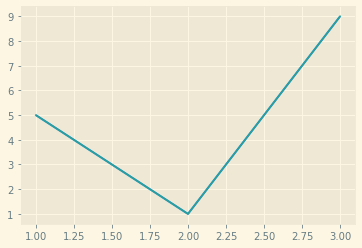

```python
style.use('Solarize_Light2')
plt.plot([1,2,3], [5,1,9])
plt.show()
```

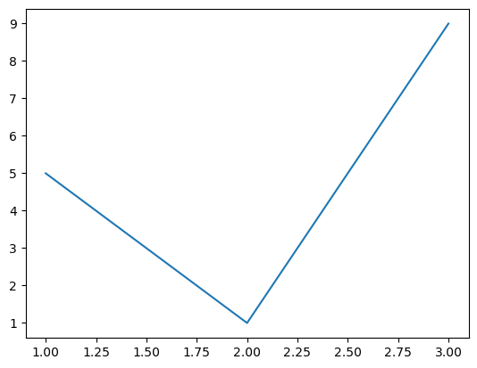

```python
style.use('default')
plt.plot([1,2,3], [5,1,9])
plt.show()
```

```python
style.available
```

```
['Solarize_Light2',
 '_classic_test_patch',
 'bmh',
 'classic',
 'dark_background',
 'fast',
 'fivethirtyeight',
 'ggplot',
 'grayscale',
 'seaborn',
 'seaborn-bright',
 'seaborn-colorblind',
 'seaborn-dark',
 'seaborn-dark-palette',
 'seaborn-darkgrid',
 'seaborn-deep',
 'seaborn-muted',
 'seaborn-notebook',
 'seaborn-paper',
 'seaborn-pastel',
 'seaborn-poster',
 'seaborn-talk',
 'seaborn-ticks',
 'seaborn-white',
 'seaborn-whitegrid',
 'tableau-colorblind10']
```

```python
red_wine = pd.read_csv('winequality-red.csv', sep=';')
red_corr = red_wine.corr()['quality'][:-1]

white_wine = pd.read_csv('winequality-white.csv', sep=';')
white_corr = white_wine.corr()['quality'][:-1]
```

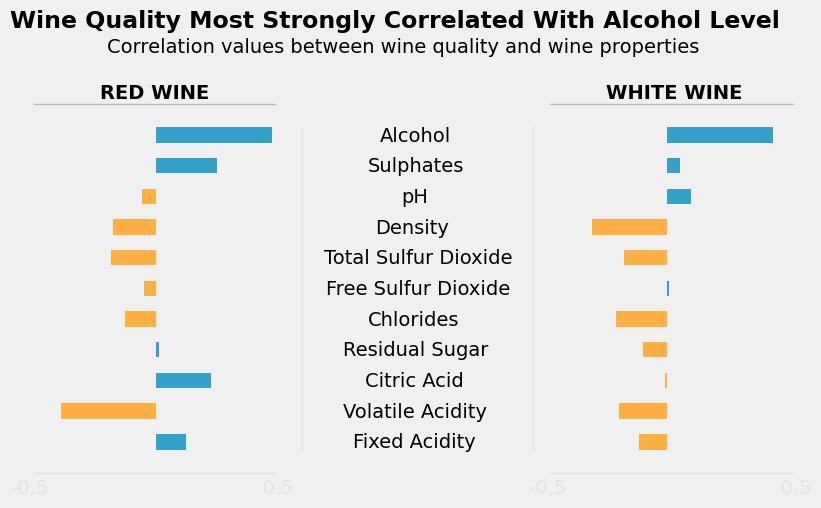

```python
style.use('fivethirtyeight')
fig, ax = plt.subplots(figsize=(9, 5))

## Use the left parameter inside barh to separate the two charts
## left: The x coordinates of the left sides of the bars.

## Generate colomap to separate positive and negative correlation values
white_positive = white_corr >= 0
white_colormap = white_positive.map({True:'#33A1C9',
                                     False:'#ffae42'})
red_positive = red_corr >= 0
red_colormap = red_positive.map({True:'#33A1C9',
                                False:'#ffae42'})

ax.barh(white_corr.index, white_corr, left=2, height=0.5, color=white_colormap)
ax.barh(red_corr.index, red_corr, height=0.5, left = -0.1, color=red_colormap)
ax.grid(False)
ax.set_xticklabels([])
ax.set_yticklabels([])

## Move the y_ticklabels in the middle of the chart
x_coords = {'Alcohol': 0.82, 'Sulphates': 0.77, 'pH': 0.91,
            'Density': 0.80, 'Total Sulfur Dioxide': 0.59,
            'Free Sulfur Dioxide': 0.6, 'Chlorides': 0.77,
            'Residual Sugar': 0.67, 'Citric Acid': 0.76,
            'Volatile Acidity': 0.67, 'Fixed Acidity': 0.71}
y_coord = 9.8
for label, xcoor in x_coords.items():
    ax.text(xcoor, y_coord, label)
    y_coord -= 1

## add verticle lines to visually separate the laebls from the bar charts
ax.axvline(x=0.5, ymin=0.1, ymax=0.9, linewidth=1, color='grey', alpha=0.1)
ax.axvline(x=1.45, ymin=0.1, ymax=0.9, linewidth=1, color='grey', alpha=0.1)

## add horizontal lines
ax.axhline(-1, xmin=0.01, xmax=0.32, linewidth = 1, color='grey', alpha=0.1)
ax.axhline(-1, xmin=0.67, xmax=0.98, linewidth = 1, color='grey', alpha=0.1)

ax.text(-0.7, -1.7, '-0.5'+' '*35+'0.5', color='grey', alpha=0.1 )
ax.text(1.43, -1.7, '-0.5'+' '*35+'0.5', color='grey', alpha=0.1 )

ax.axhline(11, xmin=0.01, xmax=0.32, linewidth=1, color='grey', alpha=0.5)
ax.axhline(11, xmin=0.67, xmax=0.98, linewidth=1, color='grey', alpha=0.5)

ax.text(-0.33, 11.2, 'RED WINE', weight='bold')
ax.text(1.75, 11.2, 'WHITE WINE', weight='bold')

### add title and subtitles

ax.text(-0.7, 13.5, 'Wine Quality Most Strongly Correlated With Alcohol Level', size=17, weight='bold')
ax.text(-0.3, 12.7, 'Correlation values between wine quality and wine properties')





plt.show()
```